# A3: Incarceration

### Introduction

I am choosing to work with two datasets provided, one about prison rates per 100,000 starting 1990 for the US and another for WA State only. I am choosing to work with this data since it is already normalized for per 100,000 persons for each group. I want to see the differences between “state” for the US dataset and “year” for both datasets. Additionally, I want to compare the numbers between the “white_jail_pop_rate” to other groups, such as “black_jail_pop_rate” and “native_jail_pop_rate”. These variables can show how Black and Native individuals compare in terms of prison rate to white people by year and state since 1990.

### The Dataset

This data was collected and generated by Vera. It was created with information collected from the US Department of Justice and BJS. It was collected for both the government and people to have access to incarceration rates in the US. The datasets I am working with both have 23 columns, with the one focusing on WA having 1131 rows and the other one having 91031 rows. This data should be considered only with the knowledge of racism in the United States. Otherwise, this data can look like certain groups of people commit crime at a higher rate for no reason. For example, understanding that 30 years ago the United States had more racism involved in the system is important, and also understanding that those in less fortunate circumstances often commit crimes at a higher rate. Finally, it is important to consider the biases of law-enforcing officials, and how that may have an impact on the data. One limitation is that the prison rate isn’t available for certain years. Another limitation is the missing values from different counties. This data doesn’t show the reason for incarceration, so that is another thing that is important but isn’t available with the data set.

### Trends Over Time Chart

This graph shows the rate of jailing for Black and white individuals from 1990 to 2018. Since often times in the news wen see a lot of police bias towards Black people, I thought these two races would be interesting to compare to see the difference. It is clear that Black people are jailed at a much higher rate than white people, and it seems like the trend was for a higher jailing average around year 2000, then dropped in recent years. For white poeple, it looks like it is way less but steadily increasing throughout the years.

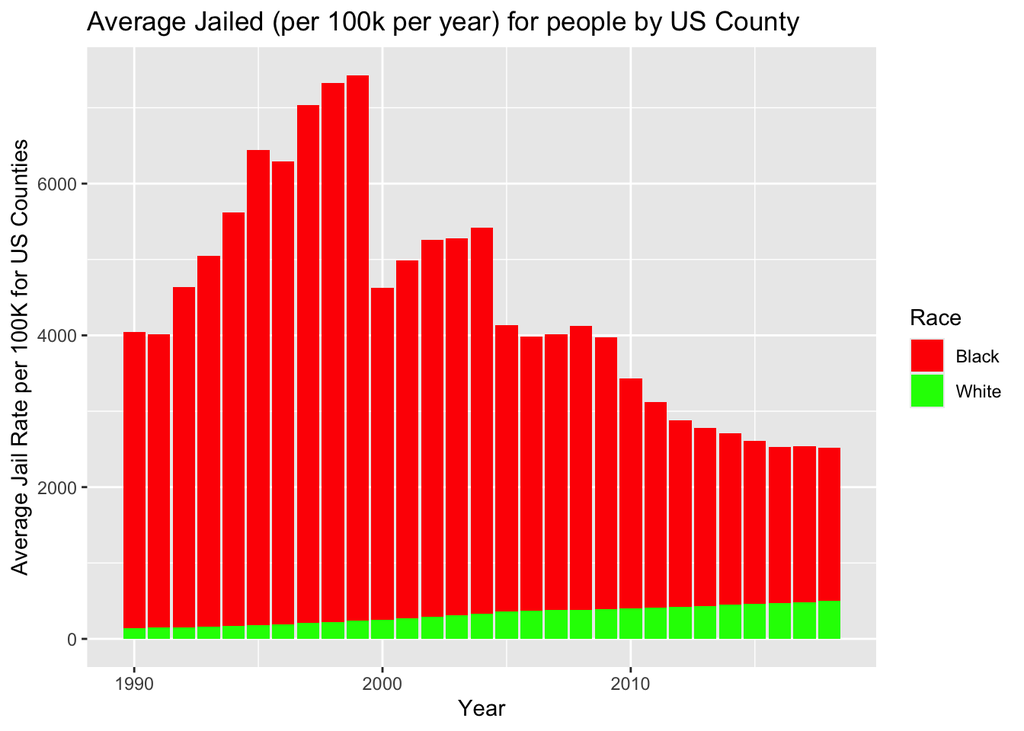

### Variable Comparison Chart

I decided to graph the rate of jailing for Native people in WA state throughout the years. It seems like it really started to increase around 2005, with it peaking around 2015. Then, in recent years it has gone down. This makes me wonder what happened in those few years to have such a high jailing rate compared to other years.

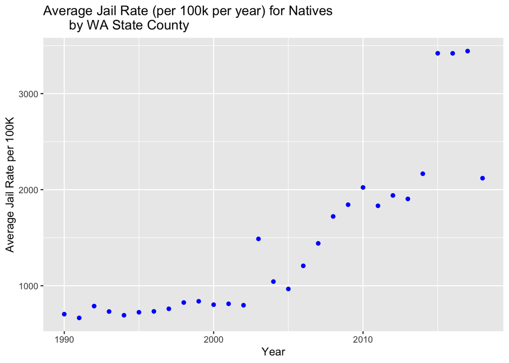

### Map

This map shows the rate of Black jailing in 2018. It can be seen that States such as Utah and Kentucky have a high rate of incarceration for Black individuals. It makes me wonder why Utah has such a high jailing rate.

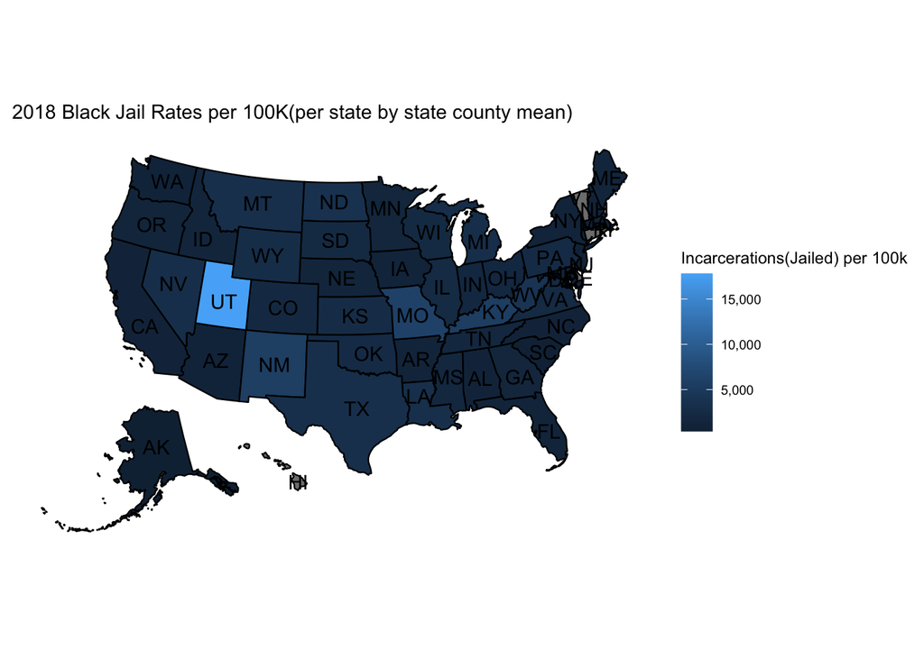